# Completely Randomized Design (CRD)

## Today’s goals

Explore key concepts in CRD:

1. Homogeneous experimental unit
2. Treatment randomization
3. The effects model
4. The ANOVA table
5. The linear model assumptions

## Motivational example - Treatment design

- 2-way factorial
- N fertilizer rates: 0, 100, 200 kg N/ha
- K fertilizer rates: 0, 30, 60 kg K/ha
- 3 x 3 = **9 treatment combinations**

## Experimental design

Assuming we have **homogeneous** experimental material (e.g., same soil type, topography, etc.)

- Thus, we can use a **completely randomized design (CRD)**

## Treatment randomization

- Randomization guards against unknown or uncontrollable sources of bias
- Avoid systematic patterns
- Eliminate selective assignment of EU to Trt (conscious or unconscious!)
- Randomization allows for valid inference on **CAUSATION**

## Treatment randomization - CRD

- Randomization of a treatment to a EU is **unrestricted**.
- That means that replications of same treatment could, by random chance, fall right next to each other.

In our motivational example:

- 4 replicates
- Total observations: **9 x 4 = 36 EUs**

## Homogeneous Experimental Material - CRD ✅

Because the experimental material is homogeneous (e.g., same soil texture class), this should not be an issue when estimating treatment means and performing comparisons. 👍

## The effects model

$$y_{ijk} = \mu + \alpha_{i} + \beta_{j} + \alpha\beta_{ij} + e_{ijk}$$

- $y_{ijk}$ is the observation on the kth rep. from ith N rate and jth K rate
- $\mu$ is the overall mean
- $\alpha_{i}$ is the differential effect of ith N rate
- $\beta_{j}$ is the differential effect of jth K rate
- $\alpha\beta_{ij}$ is the differential effect of the combination of the ith N rate and ith K rate
- $e_{ijk}$ is the residual corresponding to the kth replicate of N rate i and K rate j.

## The ANOVA table

In the following ANOVA table…

- *n* is number of levels in N rate = 3
- *k* is number of levels in K rate = 3
- *r* is number of replicates = 4
- *N* is total number of obserevations or EUs = 3 x 3 x 4 = 36

## The ANOVA table

```r
library(dplyr)
library(flextable)
tribble(~`Source of variation`,~`df`,~SS,~MS,~`F ratio`,
        #"Overall mean", "1", NA_character_, NA, NA,
        "N rate", "dfn =\nn - 1 =\n3 - 1 = 2", "SSn", "MSn =\nSSn / dfn ", "MSn / MSe",
        "K rate", "dfk =\nk - 1 =\n3 - 1 = 2", "SSk", "MSk =\nSSk / dfk", "MSk / MSe",
        "N x K", "dfnk =\n(n - 1) x (k - 1) =\n(3-1) x (3-1) = 4", "SSnk", "MSnk =\nSSnk / dfnk", "MSnk / MSe",
        "Error", "dfe =\nnk(r - 1) =\n3x3(4-1) =\n9x3 = 27", "SSe", "MSe =\nSSe / dfe", "",
        "TOTAL", "dft =\nN -1 = 35", "SSt", "", ""
        ) %>%
  regulartable() %>%
  fontsize(size = 16, part = "all") %>%
  border_inner_h(part="all") %>%
  autofit()
```

| Source of variation | df | SS | MS | F ratio |
| --- | --- | --- | --- | --- |
| N rate | dfn = n - 1 = 3 - 1 = 2 | SSn | MSn = SSn / dfn | MSn / MSe |
| K rate | dfk = k - 1 = 3 - 1 = 2 | SSk | MSk = SSk / dfk | MSk / MSe |
| N x K | dfnk = (n - 1) x (k - 1) = (3-1) x (3-1) = 4 | SSnk | MSnk = SSnk / dfnk | MSnk / MSe |
| Error | dfe = nk(r - 1) = 3x3(4-1) = 9x3 = 27 | SSe | MSe = SSe / dfe |  |
| TOTAL | dft = N -1 = 35 | SSt |  |  |

```r
  #knitr::kable()
```

- Each component of effects model has a row in the table
- The larger is the F ratio value, the more evidence towards an effect being significant.

## The ANOVA table - let’s think about it

- What can I do to increase the chances of finding a significant effect? In other words, how can I $\uparrow$ F ratios?
1. Have more variability explained by treatment ($\uparrow$ SSn ~ MSn)
2. Have less variability explained by error ($\downarrow$ MSe), through
3. Less noise in the error, or
4. More dfe

## ANOVA table - motivational example

```r
library(car)
library(emmeans)
library(multcomp)
# trt
trt <- data.frame(trt = 1:16,
                  n_code = rep(c("N1", "N2", "N3", "N4"),
                               each = 4
                               ),
                  # the study had P, I'm replacing for K
                  k_code = rep(c("K1", "K2", "K3", "K4"),
                               4
                               )
                  ) %>%
  mutate(nrate_kgha = case_when(
    n_code == "N1" ~ 0,
    n_code == "N2" ~ 100,#65,
    n_code == "N3" ~ 200,#95,
    n_code == "N4" ~ 120
  )) %>%
  mutate(krate_kgha = case_when(
    k_code == "K1" ~ 0,
    k_code == "K2" ~ 30,#50,
    k_code == "K3" ~ 60,#70,
    k_code == "K4" ~ 90
  ))

# data
df <- read_csv("files/On-Station_Trial_on_Nitrogen_and_Phosphate_Fertilization_of_Wheat__Balkh__Afghanistan__2018-19.csv") %>%
  janitor::clean_names() %>%
  dplyr::select(rep, trt, yield_kg_ha) %>%
  left_join(trt) %>%
  filter(nrate_kgha != 120) %>%
  filter(krate_kgha != 90) %>%
    mutate(rep = factor(rep),
         nrate_kgha = factor(nrate_kgha),
         krate_kgha = factor(krate_kgha)
         )  %>%
  dplyr::select(rep, trt, nrate_kgha, krate_kgha, yield_kg_ha)
set.seed(298)
df_rep4 <- df %>%
  group_by(trt, nrate_kgha, krate_kgha) %>%
  summarise(yield_kg_ha = mean(yield_kg_ha)) %>%
  ungroup() %>%
  mutate(e = rnorm(nrow(.), 0,300)) %>%
  mutate(yield_kg_ha = yield_kg_ha + e) %>%
  mutate(rep = "4") %>%
  dplyr::select(rep, trt, nrate_kgha, krate_kgha, yield_kg_ha)
df_all <- df %>%
  bind_rows(df_rep4)

# lm
options(contrasts = c("contr.sum", "contr.poly"))

lm2w <- lm(yield_kg_ha ~ nrate_kgha*krate_kgha,
           data = df_all)

Anova(lm2w, type = 3) %>%
  as.data.frame() %>%
  rownames_to_column(var = "Source of variation") %>%
  mutate(`Pr(>F)` = ifelse(`Pr(>F)` < 0.001,
                           "<0.001",
                           round(`Pr(>F)`,3))) %>%
  regulartable() %>%
  fontsize(size = 20, part = "all") %>%
  #border_inner_h(part="all") %>%
  autofit()
```

| Source of variation | Sum Sq | Df | F value | Pr(>F) |
| --- | --- | --- | --- | --- |
| (Intercept) | 836,785,505.5 | 1 | 1,917.9470762 | <0.001 |
| nrate_kgha | 1,490,936.1 | 2 | 1.7086437 | 0.2 |
| krate_kgha | 470,561.8 | 2 | 0.5392735 | 0.589 |
| nrate_kgha:krate_kgha | 11,108,159.3 | 4 | 6.3650904 | <0.001 |
| Residuals | 11,779,891.6 | 27 |  |  |

- What is significant here (say at $\alpha = 0.05$)?
- But wait, before inference, need to check model assumptions (based on residuals)!

## The linear model residual(s)

$$\hat{e}_{ijk} = y_{ijk} - \hat{y}_{ijk}$$
Or, in other words…

$$residual = observed - predicted$$

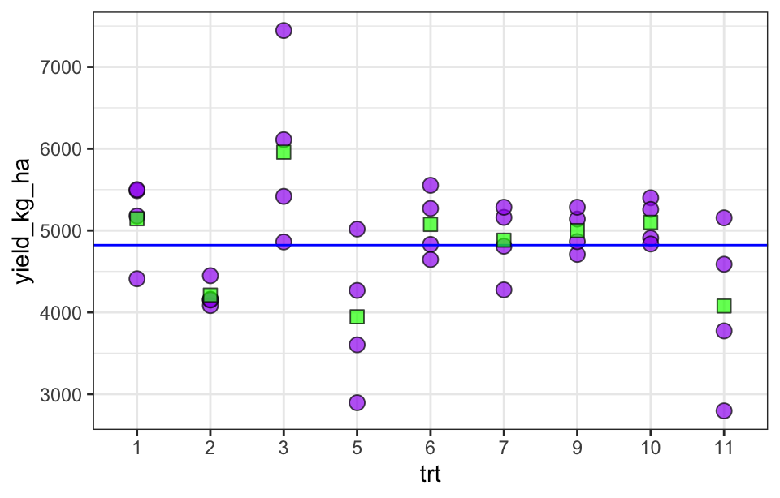

```r
df_all %>%
  mutate(trt = factor(trt)) %>%
  ggplot(aes(x = trt, y = yield_kg_ha))+
  geom_point(shape = 21,
             fill = "purple",
             size = 3,
             alpha = .7)+
  geom_hline(yintercept = mean(df_all$yield_kg_ha),
             color = "blue")+
  geom_point(data = df_all %>%
               mutate(trt = factor(trt)) %>%
               group_by(trt) %>%
               summarise(mean = mean(yield_kg_ha)),
             aes(y = mean),
             shape = 22,
             fill = "green",
             size = 3,
             alpha = .7
               )+
  theme_bw()
```

## The linear model assumptions are based on the residuals!

$$e_{ijk} \sim iidN(0, \sigma^2)$$
$e_{ijk}$ is the residual corresponding to the kth replicate of N rate i and K rate j.

Random experimental errors (**residuals**) are assumed to be:

- Mutually independent
- Normally distributed with mean 0 and common and homogeneous variance $\sigma^2$ across trts
- No extreme observations (outliers)

## Studentized residuals

- There are different types of residuals, including raw residual (the previous formula).
- Raw residuals are not useful to assess all assumptions (e.g., outliers)
- That limitation is addressed if we calculated the **studentized residuals**

## Studentized residuals

**Studentized residuals** are the raw residuals divided by their standard deviation:

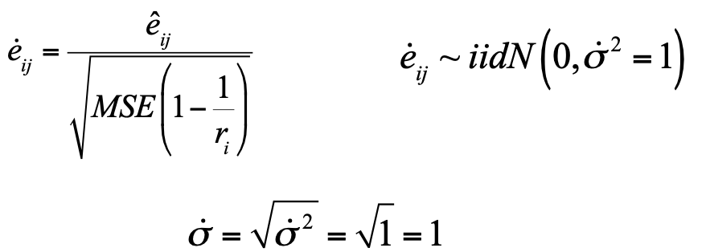

- ~95% of studentized residuals within ± 2 sd
- ~99% of studentized residuals within **± 3 sd**

## Valid analysis depend on valid assumptions!

- If model assumptions are not met, inference is meaningless
- Validity and repeatability of results is **QUESTIONABLE**
- Always check residuals before making inference! If something is wrong with assumptions, need to fix before proceeding with inference!

## Checking assumptions - residual independence

```r
library(broom)
lm2w_aug <- augment(lm2w) %>%
  mutate(.studresid=rstudent(lm2w))

ggplot(lm2w_aug, aes(x=.fitted, y=.studresid))+
  geom_hline(yintercept = 0, color="red")+
  geom_point(shape = 21,
             fill = "purple",
             size = 3,
             alpha = .7)+
  geom_smooth()+
  geom_hline(yintercept = c(-3,3), color = "red")+
  theme_bw()
```

[output not shown]

- No clear pattern (evidenced by `geom_smooth`) ✅

## Checking assumptions - residual homoscedasticity

```r
ggplot(lm2w_aug, aes(x=.fitted, y=.studresid))+
  geom_hline(yintercept = 0, color="red")+
  geom_point(shape = 21,
             fill = "purple",
             size = 3,
             alpha = .7)+
  geom_smooth()+
  geom_hline(yintercept = c(-3,3), color = "red")+
  theme_bw()
```

[output not shown]

- Data spread is even and centered around zero (evidenced by `geom_smooth`) ✅

## Checking assumptions - residual normality

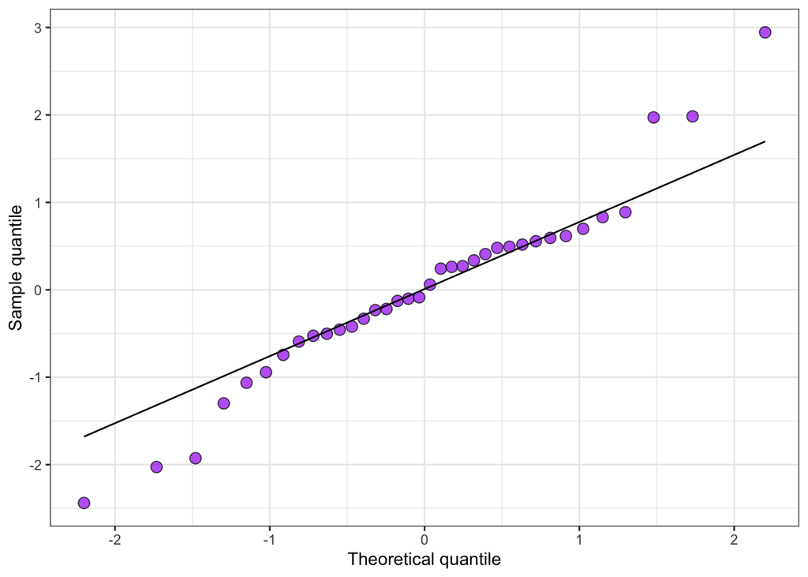

```r
ggplot(lm2w_aug, aes(sample=.studresid))+
  stat_qq(  shape = 21,
            fill = "purple",
            size = 3,
            alpha = .7
  )+
  stat_qq_line()+
  labs(x = "Theoretical quantile",
       y = "Sample quantile")+
  theme_bw()
```

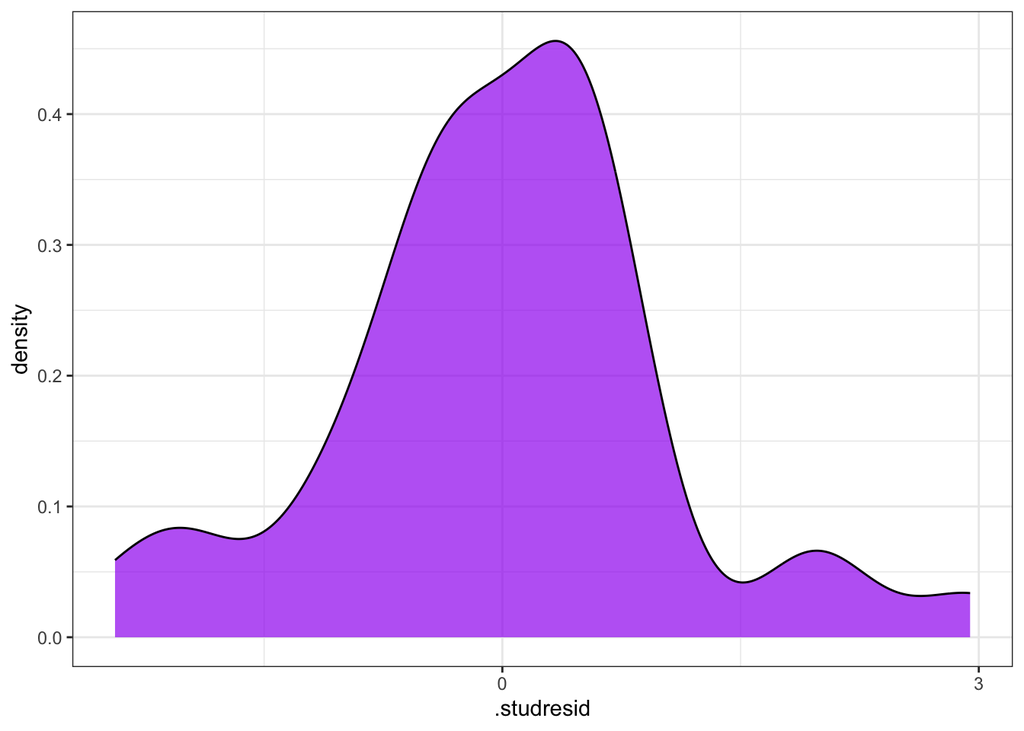

```r
ggplot(lm2w_aug, aes(x=.studresid))+
  geom_density(color = "black",
               fill = "purple",
               alpha = .7)+
  scale_x_continuous(breaks = c(-3,0,3))+
  theme_bw()
```

- It’s common for some residuals in the tails being off, especially with low N (N=36). Nothing to worry here ✅

## Checking assumptions - residual outliers

```r
ggplot(lm2w_aug, aes(x=.fitted, y=.studresid))+
  geom_hline(yintercept = 0, color="red")+
  geom_point(shape = 21,
             fill = "purple",
             size = 3,
             alpha = .7)+
  geom_smooth()+
  geom_hline(yintercept = c(-3,3), color = "red")+
  theme_bw()
```

[output not shown]

## Checking assumptions - summary

We confirmed that residuals were:

- ✅ Independent
- ✅ Homoscedastic (homogeneous variance)
- ✅ Normally distributed
- ✅ No outliers
- Therefore, **the model can be used for inference!**

## Summary

- CRD is randomized without restrictions
- Each term of the effects model has a row in the ANOVA table
- Raw vs. Studentized residuals
- If model assumptions are not met, inference is meaningless
- Model residual assumptions: iidN(0,$\sigma^2$)